# Cardio Good Fitness Project

The following serves as an analysis on the customer base of Cardio Good Fitness

```python
import numpy as np
import pandas as pd
import matplotlib.pyplot as plt
from matplotlib.ticker import PercentFormatter
import seaborn as sns
```

### Uploading data and sanity checks

```python
raw_data = pd.read_csv('CardioGoodFitness.csv')
raw_data.head()
```

|  | Product | Age | Gender | Education | MaritalStatus | Usage | Fitness | Income | Miles |
| --- | --- | --- | --- | --- | --- | --- | --- | --- | --- |
| 0 | TM195 | 18 | Male | 14 | Single | 3 | 4 | 29562 | 112 |
| 1 | TM195 | 19 | Male | 15 | Single | 2 | 3 | 31836 | 75 |
| 2 | TM195 | 19 | Female | 14 | Partnered | 4 | 3 | 30699 | 66 |
| 3 | TM195 | 19 | Male | 12 | Single | 3 | 3 | 32973 | 85 |
| 4 | TM195 | 20 | Male | 13 | Partnered | 4 | 2 | 35247 | 47 |

```python
raw_data.info() #No missing data
```

```
<class 'pandas.core.frame.DataFrame'>
RangeIndex: 180 entries, 0 to 179
Data columns (total 9 columns):
 #   Column         Non-Null Count  Dtype
---  ------         --------------  -----
 0   Product        180 non-null    object
 1   Age            180 non-null    int64
 2   Gender         180 non-null    object
 3   Education      180 non-null    int64
 4   MaritalStatus  180 non-null    object
 5   Usage          180 non-null    int64
 6   Fitness        180 non-null    int64
 7   Income         180 non-null    int64
 8   Miles          180 non-null    int64
dtypes: int64(6), object(3)
memory usage: 12.8+ KB
```

```python
raw_data.describe()
```

|  | Age | Education | Usage | Fitness | Income | Miles |
| --- | --- | --- | --- | --- | --- | --- |
| count | 180.000000 | 180.000000 | 180.000000 | 180.000000 | 180.000000 | 180.000000 |
| mean | 28.788889 | 15.572222 | 3.455556 | 3.311111 | 53719.577778 | 103.194444 |
| std | 6.943498 | 1.617055 | 1.084797 | 0.958869 | 16506.684226 | 51.863605 |
| min | 18.000000 | 12.000000 | 2.000000 | 1.000000 | 29562.000000 | 21.000000 |
| 25% | 24.000000 | 14.000000 | 3.000000 | 3.000000 | 44058.750000 | 66.000000 |
| 50% | 26.000000 | 16.000000 | 3.000000 | 3.000000 | 50596.500000 | 94.000000 |
| 75% | 33.000000 | 16.000000 | 4.000000 | 4.000000 | 58668.000000 | 114.750000 |
| max | 50.000000 | 21.000000 | 7.000000 | 5.000000 | 104581.000000 | 360.000000 |

Since all values are either discreet or categorical, it merits checking what are the unique values for each variable for future ease of organization

```python
columns = raw_data.columns.to_list()
[print('The unique values for ',x,' are: ',raw_data[x].unique().tolist()) for x in columns]
```

```
The unique values for  Product  are:  ['TM195', 'TM498', 'TM798']
The unique values for  Age  are:  [18, 19, 20, 21, 22, 23, 24, 25, 26, 27, 28, 29, 30, 31, 32, 33, 34, 35, 36, 37, 38, 39, 40, 41, 43, 44, 46, 47, 50, 45, 48, 42]
The unique values for  Gender  are:  ['Male', 'Female']
The unique values for  Education  are:  [14, 15, 12, 13, 16, 18, 20, 21]
The unique values for  MaritalStatus  are:  ['Single', 'Partnered']
The unique values for  Usage  are:  [3, 2, 4, 5, 6, 7]
The unique values for  Fitness  are:  [4, 3, 2, 1, 5]
The unique values for  Income  are:  [29562, 31836, 30699, 32973, 35247, 37521, 36384, 38658, 40932, 34110, 39795, 42069, 44343, 45480, 46617, 48891, 53439, 43206, 52302, 51165, 50028, 54576, 68220, 55713, 60261, 67083, 56850, 59124, 61398, 57987, 64809, 47754, 65220, 62535, 48658, 54781, 48556, 585…
The unique values for  Miles  are:  [112, 75, 66, 85, 47, 141, 103, 94, 113, 38, 188, 56, 132, 169, 64, 53, 106, 95, 212, 42, 127, 74, 170, 21, 120, 200, 140, 100, 80, 160, 180, 240, 150, 300, 280, 260, 360]
```

```
[None, None, None, None, None, None, None, None, None]
```

## Univariate Analysis

#### Distributions in percentages

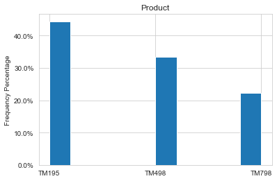

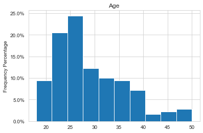

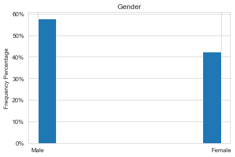

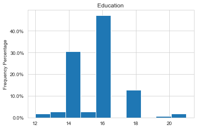

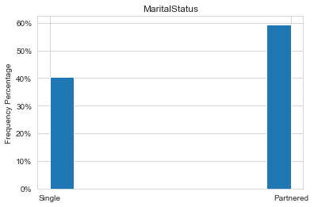

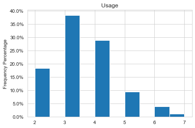

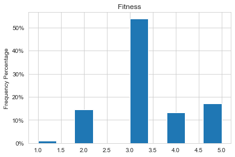

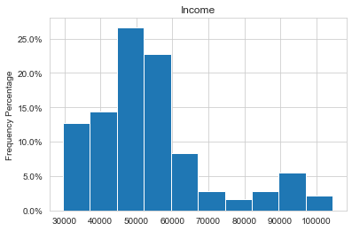

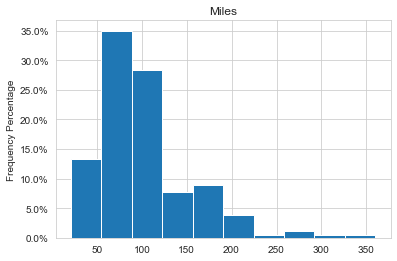

```python
for x in columns:
    raw_data[str(x)].hist(weights=np.ones(len(raw_data[str(x)])) / len(raw_data[str(x)]))
    plt.title(x)
    plt.gca().yaxis.set_major_formatter(PercentFormatter(1))
    plt.ylabel('Frequency Percentage')
    plt.show()
```

```python
# To start to manipulate the data safely, its worth moving data to a copy.
data_manip = raw_data.copy()
```

```python
# To see the spread of numerical data, we select those. (Diff. df for organization)
data_numericals = data_manip.select_dtypes(include=[np.number])

data_numericals.head()
```

|  | Age | Education | Usage | Fitness | Income | Miles |
| --- | --- | --- | --- | --- | --- | --- |
| 0 | 18 | 14 | 3 | 4 | 29562 | 112 |
| 1 | 19 | 15 | 2 | 3 | 31836 | 75 |
| 2 | 19 | 14 | 4 | 3 | 30699 | 66 |
| 3 | 19 | 12 | 3 | 3 | 32973 | 85 |
| 4 | 20 | 13 | 4 | 2 | 35247 | 47 |

#### Distributions for numerical variables to determine presence of outliers

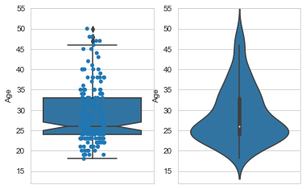

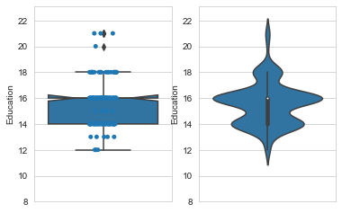

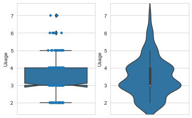

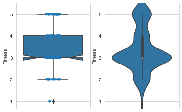

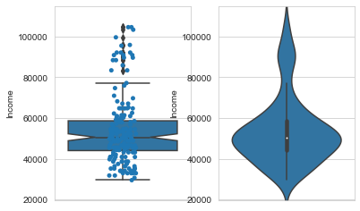

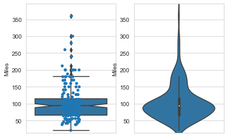

```python
for n in data_numericals.columns:
    sns.set_style('whitegrid')
    fig, axes = plt.subplots(1, 2)
    _ylim = (min(data_numericals[n].values)/1.5,max(data_numericals[n].values)*1.1)
    plt.setp(axes, ylim=_ylim)
    sns.boxplot(y = data_numericals[n],notch=True,ax = axes[0])
    sns.stripplot(y = data_numericals[n],ax=axes[0])
    sns.violinplot(y= data_numericals[n],ax=axes[1])
    plt.show()
```

Upon observing the data, we can see that some numerical variables may contain outliers. While the distribution of the outliers seem to follow the behavior of a valid distribution tail, it is worth check the lower and upper outer fences and see if any of these are "extreme outliers".

```
The quantile values for 25, 50 and 75 percentiles respectively for  Age  are given by:
0.25    24.0
0.50    26.0
0.75    33.0
Name: Age, dtype: float64
Resulting in an IQR of: 9.0
Leading to the respective lower and upper outer fences of -3.0 and 60.0
```

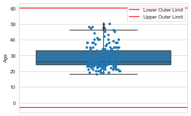

```
The quantile values for 25, 50 and 75 percentiles respectively for  Education  are given by:
0.25    14.0
0.50    16.0
0.75    16.0
Name: Education, dtype: float64
Resulting in an IQR of: 2.0
Leading to the respective lower and upper outer fences of 8.0 and 22.0
```

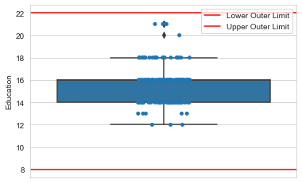

```
The quantile values for 25, 50 and 75 percentiles respectively for  Usage  are given by:
0.25    3.0
0.50    3.0
0.75    4.0
Name: Usage, dtype: float64
Resulting in an IQR of: 1.0
Leading to the respective lower and upper outer fences of 0.0 and 7.0
```

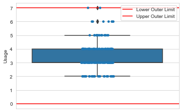

```
The quantile values for 25, 50 and 75 percentiles respectively for  Fitness  are given by:
0.25    3.0
0.50    3.0
0.75    4.0
Name: Fitness, dtype: float64
Resulting in an IQR of: 1.0
Leading to the respective lower and upper outer fences of 0.0 and 7.0
```

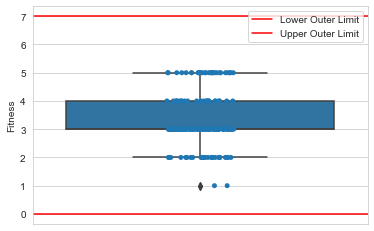

```
The quantile values for 25, 50 and 75 percentiles respectively for  Income  are given by:
0.25    44058.75
0.50    50596.50
0.75    58668.00
Name: Income, dtype: float64
Resulting in an IQR of: 14609.25
Leading to the respective lower and upper outer fences of 231.0 and 102495.75
```

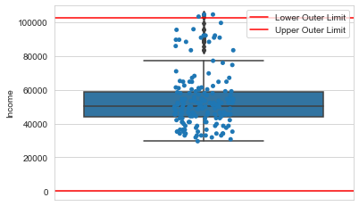

```
The quantile values for 25, 50 and 75 percentiles respectively for  Miles  are given by:
0.25     66.00
0.50     94.00
0.75    114.75
Name: Miles, dtype: float64
Resulting in an IQR of: 48.75
Leading to the respective lower and upper outer fences of -80.25 and 261.0
```

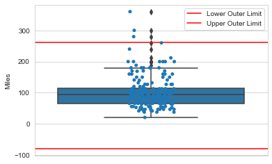

```python
for n in data_numericals.columns:
    quantile_data = data_numericals[n].quantile([0.25,0.5,0.75])
    IQR = max(quantile_data.values)-min(quantile_data.values)
    low_out = min(quantile_data.values)-3*IQR
    upper_out = max(quantile_data.values)+3*IQR
    print('The quantile values for 25, 50 and 75 percentiles respectively for ',n,' are given by:')
    print(quantile_data)
    print('Resulting in an IQR of: '+str(IQR))
    print('Leading to the respective lower and upper outer fences of '+str(low_out)+' and '+str(upper_out))
    sns.boxplot(y = data_numericals[n])
    sns.stripplot(y = data_numericals[n])
    plt.axhline(y = low_out, color = 'r', linestyle = '-',label='Lower Outer Limit')
    plt.axhline(y = upper_out, color = 'r', linestyle = '-',label='Upper Outer Limit')
    plt.legend(bbox_to_anchor = (1.0, 1),loc = 'upper right')
    plt.show()
```

Given than some numerical data falls outside the lower and upper fences, I would suggest these be treated as extreme outliers but given then distribution of the data, I would choose to substitute them for the median (versus the mean).

```python
data_num_sansout = data_numericals.copy()
```

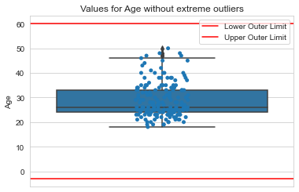

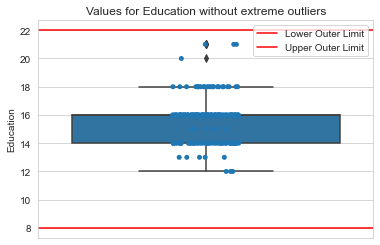

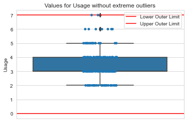

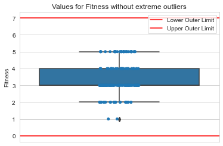

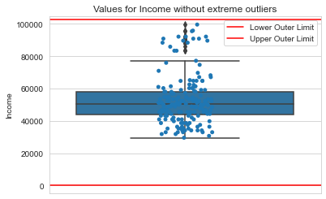

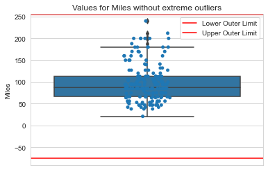

```python
for n in data_num_sansout.columns:
    quantile_data = data_num_sansout[n].quantile([0.25,0.5,0.75])
    IQR = max(quantile_data.values)-min(quantile_data.values)
    low_out = min(quantile_data.values)-3*IQR
    upper_out = max(quantile_data.values)+3*IQR
    data_num_sansout[n].iloc[(data_num_sansout[n]>upper_out)|(data_num_sansout[n]<low_out)] = np.median(data_num_sansout[n].values)

    sns.boxplot(y = data_num_sansout[n])
    sns.stripplot(y = data_num_sansout[n])
    plt.axhline(y = low_out, color = 'r', linestyle = '-',label='Lower Outer Limit')
    plt.axhline(y = upper_out, color = 'r', linestyle = '-',label='Upper Outer Limit')
    plt.legend(bbox_to_anchor = (1.0, 1),loc = 'upper right')
    plt.title('Values for '+n+' without extreme outliers')
    plt.show()
```

```python
for y in data_num_sansout.columns:
    data_manip[y]=data_num_sansout[y]
```

```python
data_manip.head()
```

|  | Product | Age | Gender | Education | MaritalStatus | Usage | Fitness | Income | Miles |
| --- | --- | --- | --- | --- | --- | --- | --- | --- | --- |
| 0 | TM195 | 18 | Male | 14 | Single | 3 | 4 | 29562.0 | 112.0 |
| 1 | TM195 | 19 | Male | 15 | Single | 2 | 3 | 31836.0 | 75.0 |
| 2 | TM195 | 19 | Female | 14 | Partnered | 4 | 3 | 30699.0 | 66.0 |
| 3 | TM195 | 19 | Male | 12 | Single | 3 | 3 | 32973.0 | 85.0 |
| 4 | TM195 | 20 | Male | 13 | Partnered | 4 | 2 | 35247.0 | 47.0 |

In the case that a model design would be desired, the data is clean from extreme outliers. It might not be a relevant effort for the scope of this analysis.

## Multivariate Analysis

```python
#To be able to appreciate the pairwise correlations of all the data, columns with strings values
# will be turned into numerical codes

for x in columns:
    if type(data_manip[x][0])==str:
        index_map = data_manip[x].unique()
        print(pd.Series(index_map))
        indx = 0
        for i in index_map:
            data_manip.loc[data_manip[x]==i,x]=indx
            indx+=1
```

[output not shown]

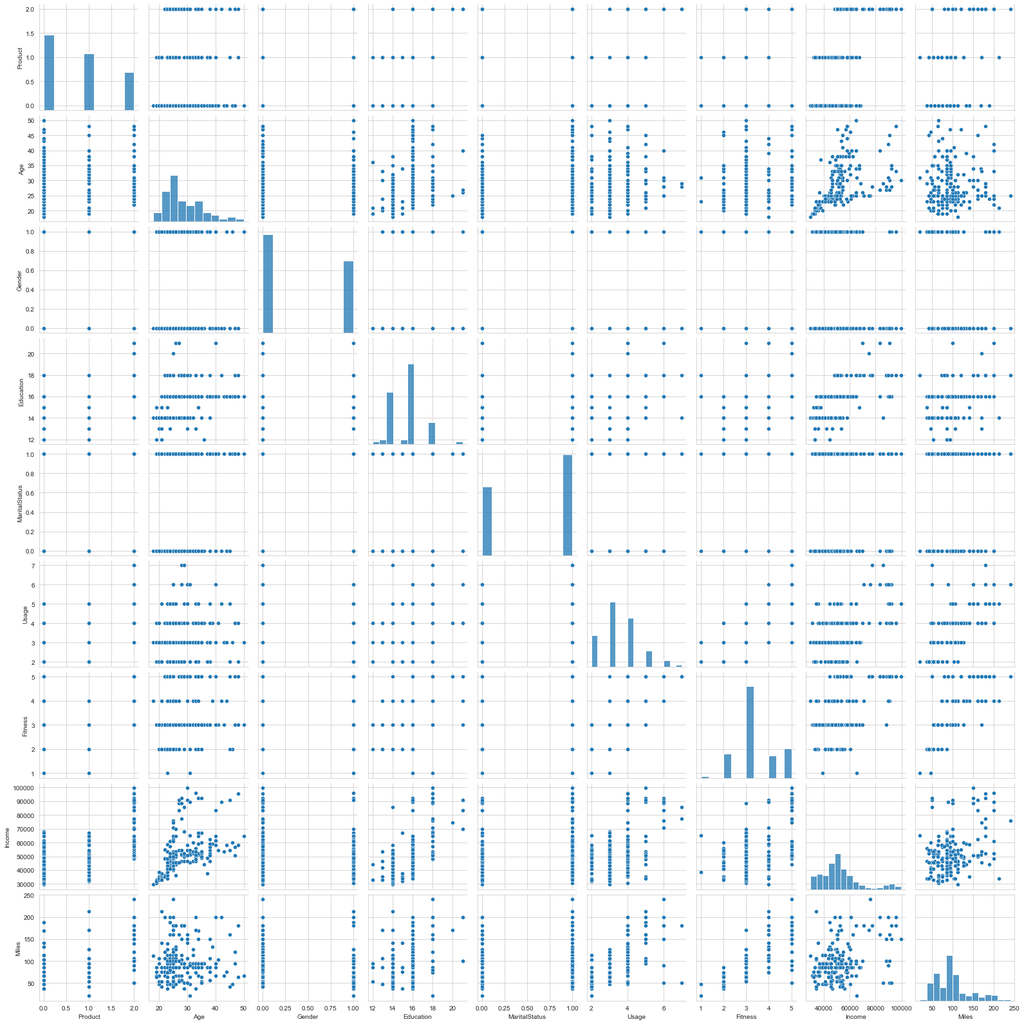

```python
#What correlations are there between pairwise comparisons of variables?
sns.pairplot(data_manip)
```

At first glance, there are some interesting multivariate qualities to explore:

#### Relations to explore related to: Product

- The third product seems to be more frequently purchased by people with higher incomes
- The third product is the least bought and the most used
- The third product seems to also be correlated with higher fitness levels

#### Relations to explore related to: Marital Status

- Usage and Miles have (as expected) a positive correlation. Furthermore, Marital Status seems to have a positive relation with miles, but this relation is not captured when observing usage (explore)
- 60% of users are partnered.
  - Is it because they have more disposable income or because it's a targeted market?

#### Relations to explore related to: Income

- When observing usage in the form of miles, the data seems to cluster between modest income/low miles and high income